# Forecasting principles and practice

Brainstorming example for noisy busy univariate TS

Nicholas Spyrison

12 Mar 2022

# Gist

I am using this to vet and flesh out some idea for a noisy univariate time series. Typically, I think about time series features approaches. For example, Rob and Priyanga did several pieces with this approach for water quality data in streams. I will be referring to Rob & George’s fpp2, https://otexts.com/fpp2/, for examples and inspiration as well. I will be focusing on a particularly noisy time series, while working in parallel with the content in the book.

# Setup

We’ll use melb-syd flight data as an example ts with noise and oddities.

```r
library(fpp2)
#library(ggplot2)

dat <- fpp2::melsyd[, "Economy.Class"]
str(dat)
```

```
##  Time-Series [1:283] from 1987 to 1993: 20.2 20.2 20 21 20.5 ...
```

```r
sum(is.na(dat))
```

```
## [1] 1
```

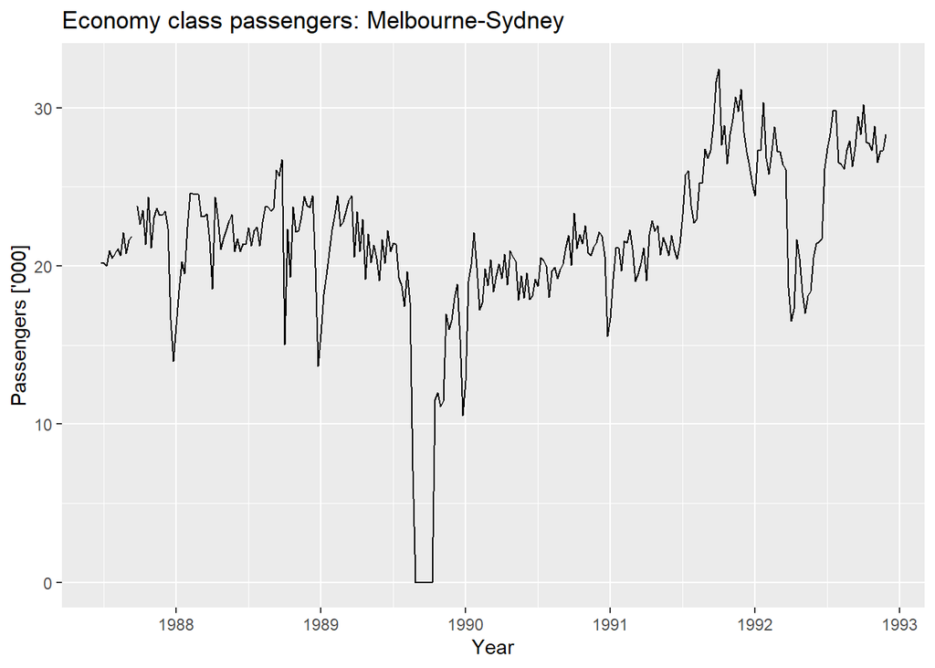

```r
autoplot(dat) +
  ggtitle("Economy class passengers: Melbourne-Sydney") +
  xlab("Year") +
  ylab("Passengers ['000]")
```

# Autocorellation

The data set is quite mess and there are few small seasonal changes. I want to see if any autocorelation is picked up on as an indication of signal shining through the noise.

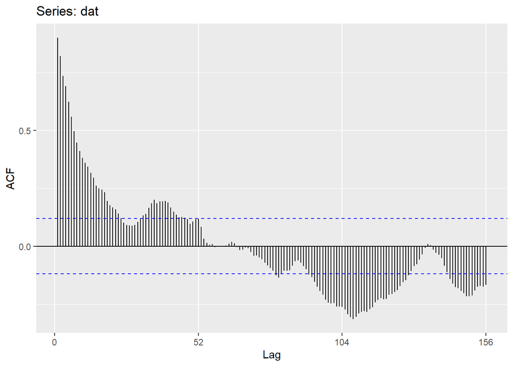

```r
ggAcf(dat, lag = 52 * (1993 - 1987) / 2)
```

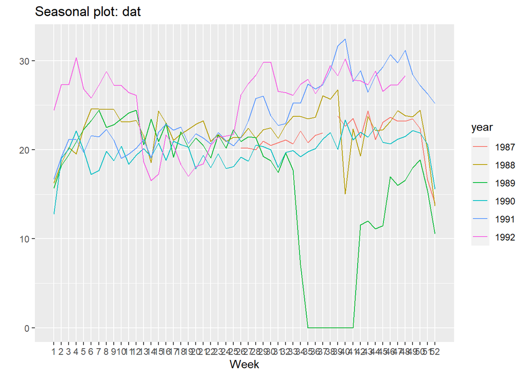

```r
ggseasonplot(dat)
```

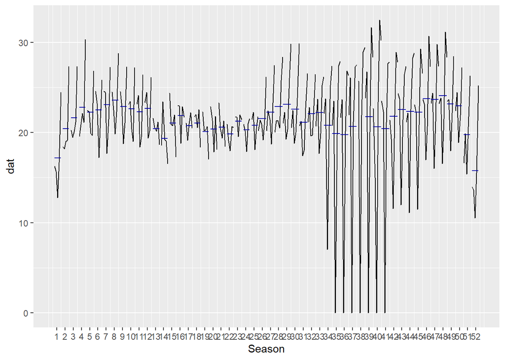

```r
ggsubseriesplot(dat)
```

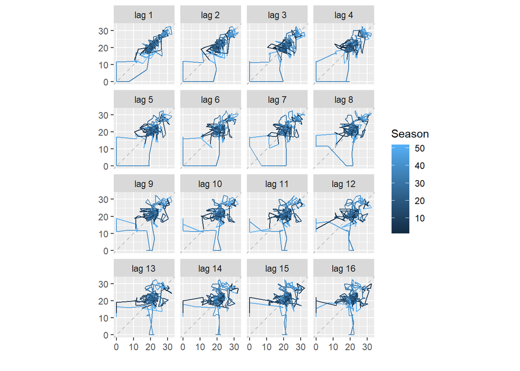

```r
gglagplot(dat)
```

# Box-cox transformation

We can use a box-cox transformation to distribute the data normally. The tranfsormation has one parameter, $\lambda$. A good value for this can be estimated with `BoxCox.lambda`. The text-book example for box-cox transformation is for growing/shrinking seasonal variation such as in the data set `elec`

```r
(lambda <- BoxCox.lambda(dat))
```

```
## [1] 2
```

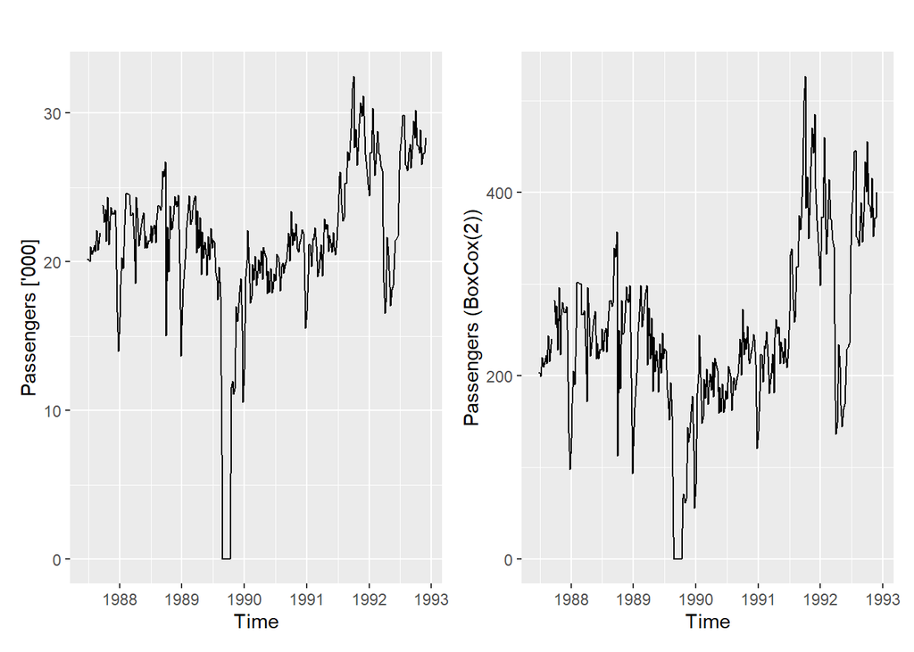

```r
dat_bc <- BoxCox(dat,lambda)
## Normalized difference doesn't plot, cause of NA?
#dat_diff <- scale(dat) - scale(dat_bc)
require(patchwork)
autoplot(dat) +
  ylab("Passengers ['000]") +
  autoplot(dat_bc) +
  ylab(paste0("Passengers (BoxCox(", round(lambda), "))"))
```

# Random walk forecasts

We can do some preliminary with random walk forecasting.

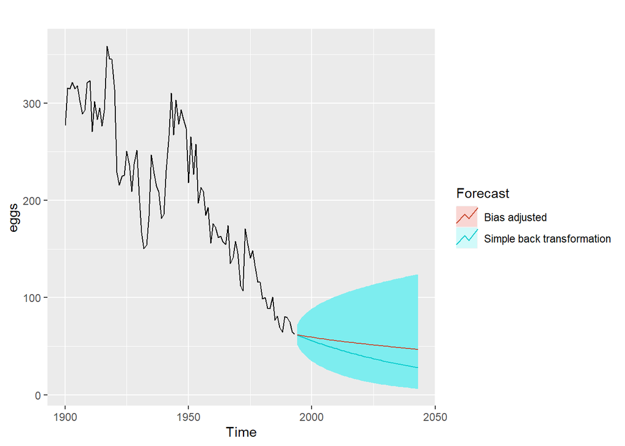

```r
fc  <- rwf(eggs, drift=TRUE, lambda=0, h=50, level=80)
fc2 <- rwf(eggs, drift=TRUE, lambda=0, h=50, level=80, biasadj=TRUE)
autoplot(eggs) +
  autolayer(fc,  series="Simple back transformation") +
  autolayer(fc2, series="Bias adjusted", PI=FALSE) +
  guides(colour=guide_legend(title="Forecast"))
```

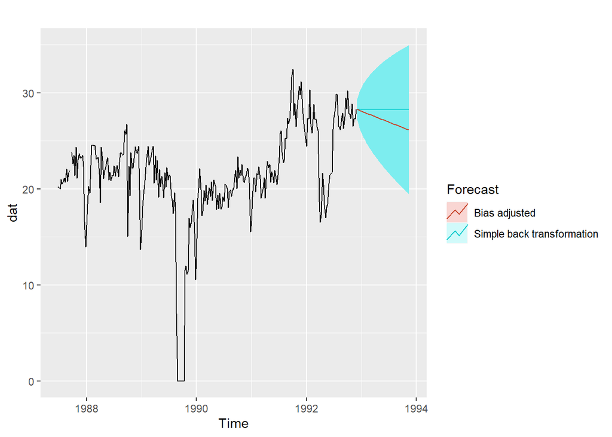

```r
fc  <- rwf(dat, drift=FALSE, lambda=lambda, h=50, level=50)
fc2 <- rwf(dat, drift=FALSE, lambda=lambda, h=50, level=50, biasadj=TRUE)
autoplot(dat) +
  autolayer(fc,  series="Simple back transformation") +
  autolayer(fc2, series="Bias adjusted", PI=FALSE) +
  guides(colour=guide_legend(title="Forecast"))
```

# Session info

```r
## Packages used
pkgs <- c("oddstream")
## Package & session info
```

# Sources & related content

- https://otexts.com/fpp2/
- https://github.com/pridiltal/oddstream